# Homework 3

Hajra Shahab; andrewID: hshahab

Fall 2020

##### This homework is due by **1:30PM ET on Wednesday, November 18**.

### Loading packages

The code chunk below appears in the Rmd file, but won’t be displayed in your html output.

### Problem 1: A few simple plots

For this problem we’ll use the `diamonds` dataset from the `ggplot2` package.

Use the `qplot` function to create a histogram of `carat` with the bars colored `steelblue`.

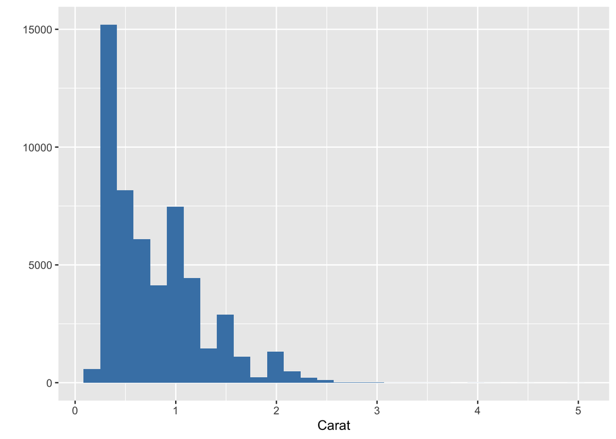

```r
qplot(carat, data = diamonds, fill = I("steelblue")) +
  xlab("Carat")
```

This time, use the `ggplot` function (not the `qplot` function!) to create a histogram of `depth`.

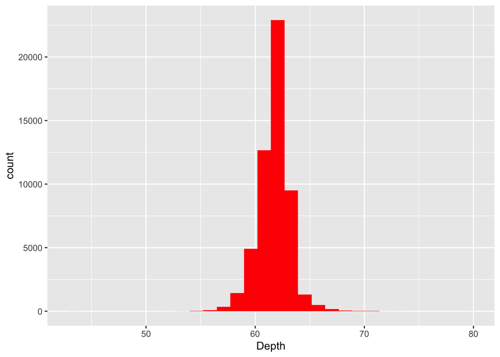

```r
diamonds.hist <- ggplot(diamonds, aes(x = depth)) +
  xlab("Depth")
diamonds.hist + geom_histogram(fill = I("red"))
```

##### (c) qplot violin plots

Use `qplot` to create violin plots showing how `price` varies across diamond `cut`. Specify `fill = cut` to get all the boxplots to be coloured differently.

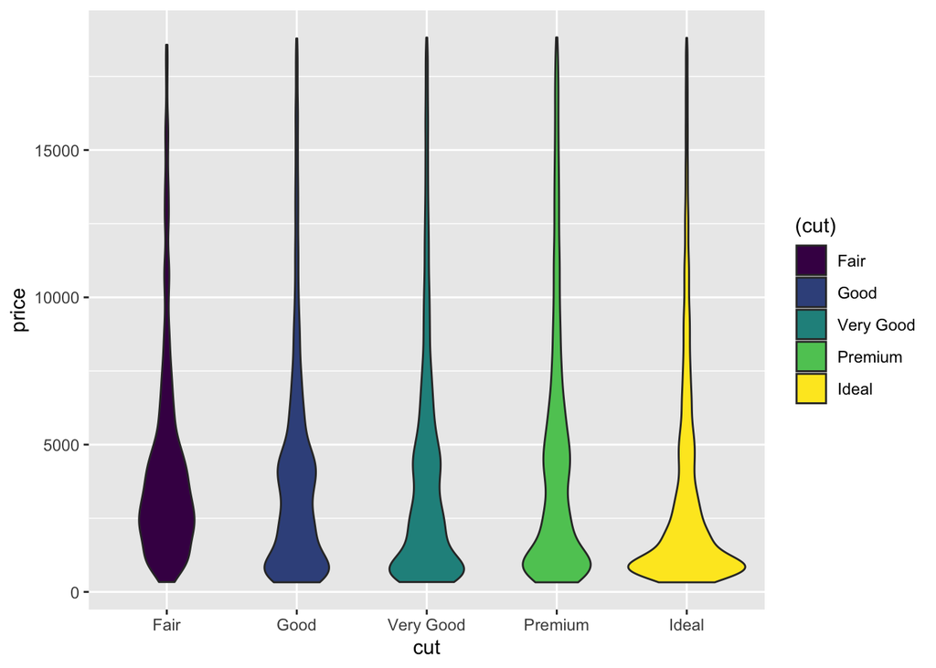

```r
price.cut <- qplot(cut, price, data=diamonds, geom = "violin", fill = (cut))
print(price.cut)
```

**Hint**: For this exercise, it will be useful to know that `violin` is a geometry (`geom`) built into `ggplot2`, and that `qplot` can be called by specifying the following arguments:

```r
qplot(x, y, data, geom, fill)
```

### Problem 2: ggplot practice

For this exercise we’ll go back to the Cars93 data set in the MASS library

##### (a) size mapping, geom_point()

Define a `ggplot` object using the Cars93 data set that you can use to view `Price` on the y-axis, `MPG.highway` on the x-axis, and set the `size` mapping to be based on `Horsepower`.

Use `geom_point()` to create a scatterplot from your `ggplot` object.

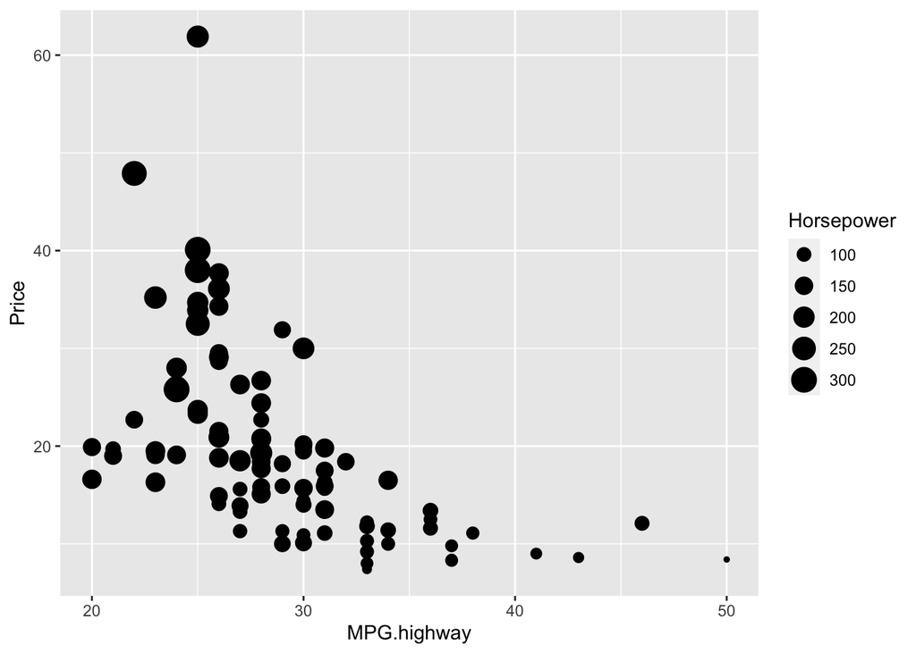

```r
Cars93 <- MASS::Cars93
mpg.price.plot <- ggplot(data = Cars93, aes(x = MPG.highway, y = Price, size = Horsepower))
mpg.price.plot + geom_point()
```

##### (b) colour mapping

Repeat part (a), this time also setting the `colour` mapping to be based on `Origin`.

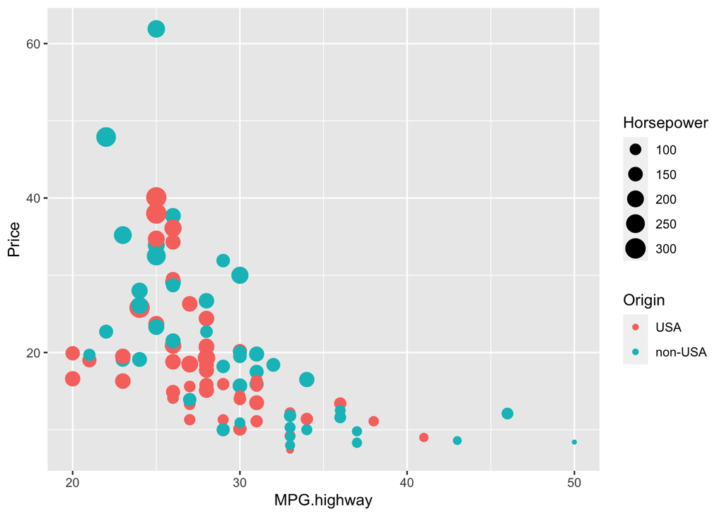

```r
mpg.price.plot2 <- ggplot(data = Cars93, aes(x = MPG.highway, y = Price, size = Horsepower, color = Origin))
mpg.price.plot2 + geom_point()
```

##### (c) changing color palette

Repeat part (b), this time using the `scale_colour_manual()` layer to specify that you want to use `cbPalette` as your color palette.

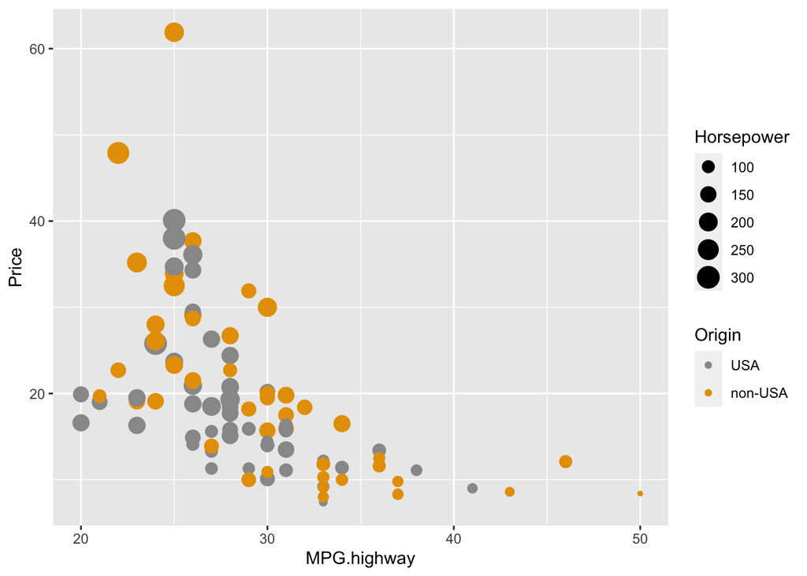

```r
cbPalette <- c("#999999", "#E69F00", "#56B4E9", "#009E73", "#F0E442", "#0072B2", "#D55E00", "#CC79A7")
mpg.price.plot2 <- ggplot(data = Cars93, aes(x = MPG.highway, y = Price, size = Horsepower, color = Origin))
mpg.price.plot2 + geom_point() + scale_colour_manual(values = cbPalette)
```

### Problem 3: More ggplot2 practice

##### (a) stat_smooth()

Repeat part 2(b), this time using `stat_smooth()` to add a layer showing the smoothed curve representing how `Price` varies with `MPG.highway`.

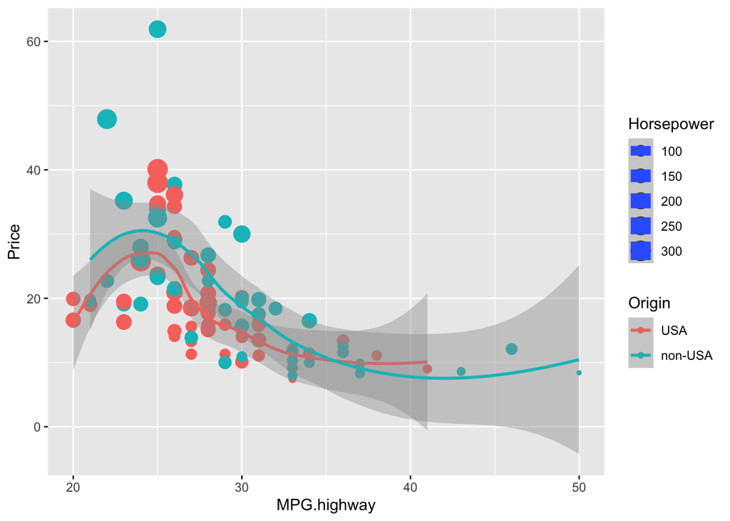

```r
mpg.price.plotsm <- ggplot(data = Cars93, aes(x = MPG.highway, y = Price, size = Horsepower, color = Origin))
mpg.price.plotsm + geom_point() + stat_smooth()
```

##### (b) facet_grid()

Use your ggplot object from 2(b) along with the `geom_point()` and `facet_grid` layers to create scatterplots of `Price` against `MPG.highway`, broken down by (conditioned on) `Origin`.

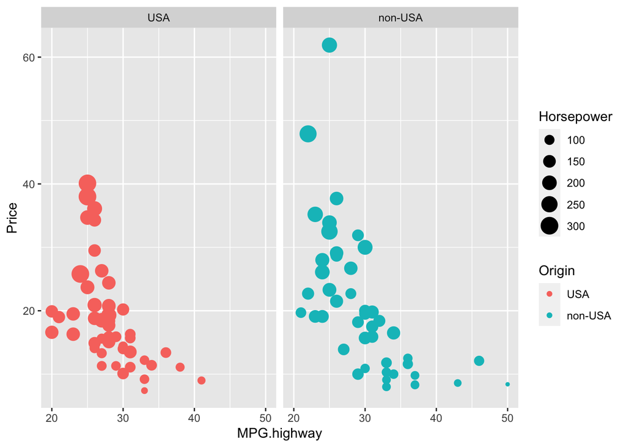

```r
mpg.price.scatplot <- ggplot(data = Cars93, aes(x = MPG.highway, y = Price, size = Horsepower, color = Origin))
mpg.price.scatplot + geom_point() + facet_grid(. ~ Origin)
```

(Your code should produce a figure with two scatterplots, one for each level of `Origin`.)

##### (c) Overlaying regression lines.

Modify your solution to part (b) to also display regression lines for each scatterplot.

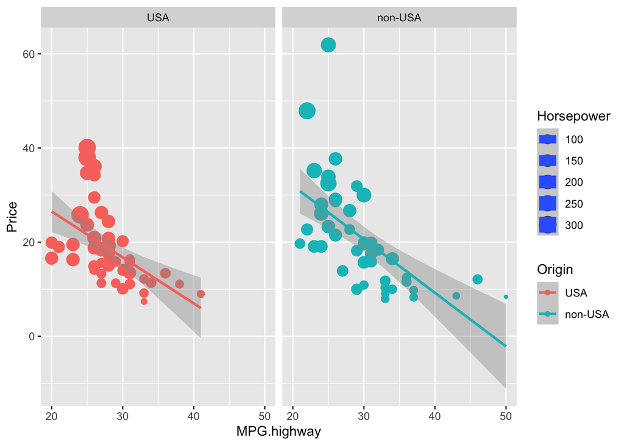

```r
mpg.price.plot4 <- ggplot(data = Cars93, aes(x = MPG.highway, y = Price, size = Horsepower, color = Origin))
mpg.price.plot4 + geom_point() + facet_grid(. ~ Origin) + geom_smooth(method = "lm")
```

### Problem 4: Visualizing data summaries

This problem uses the Adult dataset, which we load below. The main variable of interest here is `high.income`, which indicates whether the individual’s income was over $50K. Anyone for whom `high.income == 1` is considered a “high earner”.

```r
adult.data <- read_csv("http://archive.ics.uci.edu/ml/machine-learning-databases/adult/adult.data",
                       trim_ws=TRUE,
                       col_names=c("age", "type_employer", "fnlwgt", "education", "education_num","marital",
                                   "occupation", "relationship", "race","sex", "capital_gain", "capital_loss",
                                   "hr_per_week","country", "income"))
adult.data <- mutate(adult.data,
                     high.income = as.numeric(income == ">50K"))
```

##### (a) Income by education level

Use `dplyr` (tidyverse) functions to produce a summary table showing how many individuals there are in each `education` bin, and how the proportion of high earners varies across `education` levels. Your output should be a tibble with column names: `education`, `count` and `high.earn.rate`.

```r
high.edu <- adult.data %>%
group_by(education) %>%
summarize(count = n(), high.earn.rate = sum(high.income)/ n())
print(high.edu)
```

```
## # A tibble: 16 x 3
##    education    count high.earn.rate
##    <chr>        <int>          <dbl>
##  1 10th           933         0.0665
##  2 11th          1175         0.0511
##  3 12th           433         0.0762
##  4 1st-4th        168         0.0357
##  5 5th-6th        333         0.0480
##  6 7th-8th        646         0.0619
##  7 9th            514         0.0525
##  8 Assoc-acdm    1067         0.248
##  9 Assoc-voc     1382         0.261
## 10 Bachelors     5355         0.415
## 11 Doctorate      413         0.741
## 12 HS-grad      10501         0.160
## 13 Masters       1723         0.557
## 14 Preschool       51         0
## 15 Prof-school    576         0.734
## 16 Some-college  7291         0.190
```

##### (b) Constructing a bar chart

Using the `ggplot` and `geom_bar` commands along with your data summary from part **(a)** to create a bar chart showing the high earning rate on the y axis and `education` on the x axis. Specify that the color of the bars should be determined by the number of individuals in each bin.

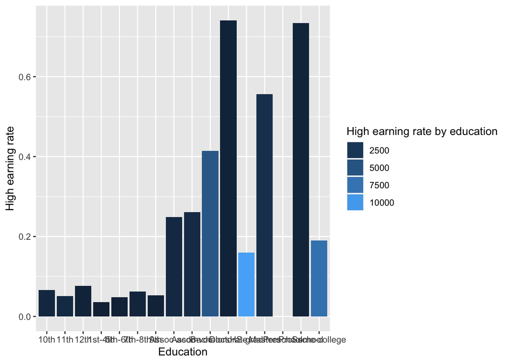

```r
p.high.income <- ggplot(data = high.edu, aes(y = high.earn.rate, x = education, fill = count))
p.high.income + geom_bar( stat = "identity", position = "dodge") +
  ylab("High earning rate") +
  xlab("Education") +
  guides(fill = guide_legend(title = "High earning rate by education"))
```

##### (c) Improve upon your plot by following example 4 [from this guide](https://rpubs.com/sediaz/rotate_x_text) to rotate the x-axis text so that it doesn’t overlap with itself. (Any reasonable rotation is fine. It doesn’t have to be -90 degrees as illustrated in the linked example.)

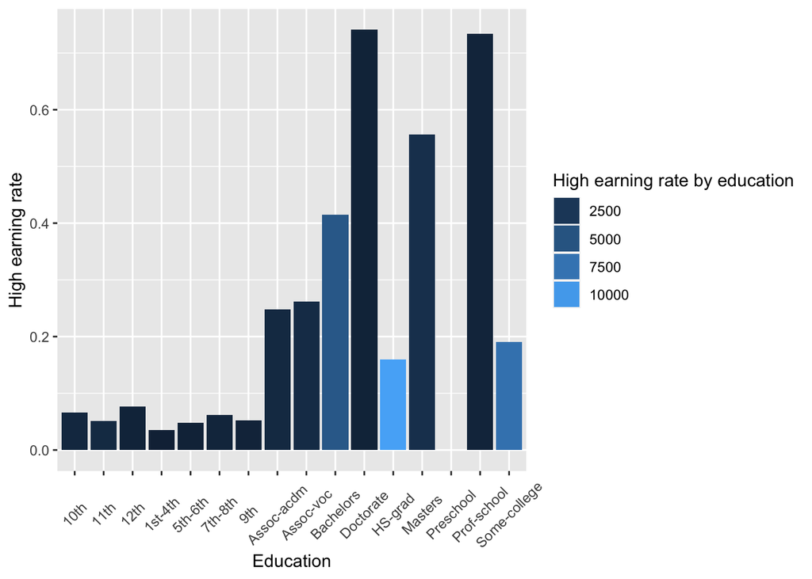

```r
p.high.income <- ggplot(data = high.edu, aes(y = high.earn.rate, x = education, fill = count))
p.high.income + geom_bar( stat = "identity", position = "dodge") +
  ylab("High earning rate") +
  xlab("Education") +
  guides(fill = guide_legend(title = "High earning rate by education")) +
  theme(axis.text.x = element_text(angle = 45, vjust = 0.5))
```

##### (d) Further improve upon your plot from part **(c)** by using `mutate()` and `factor()` to change the ordering of the `education` variable labels to something that reflects *ascending order* of educational attainment. You can use your discretion in how to break ties for the post-high school educational levels.

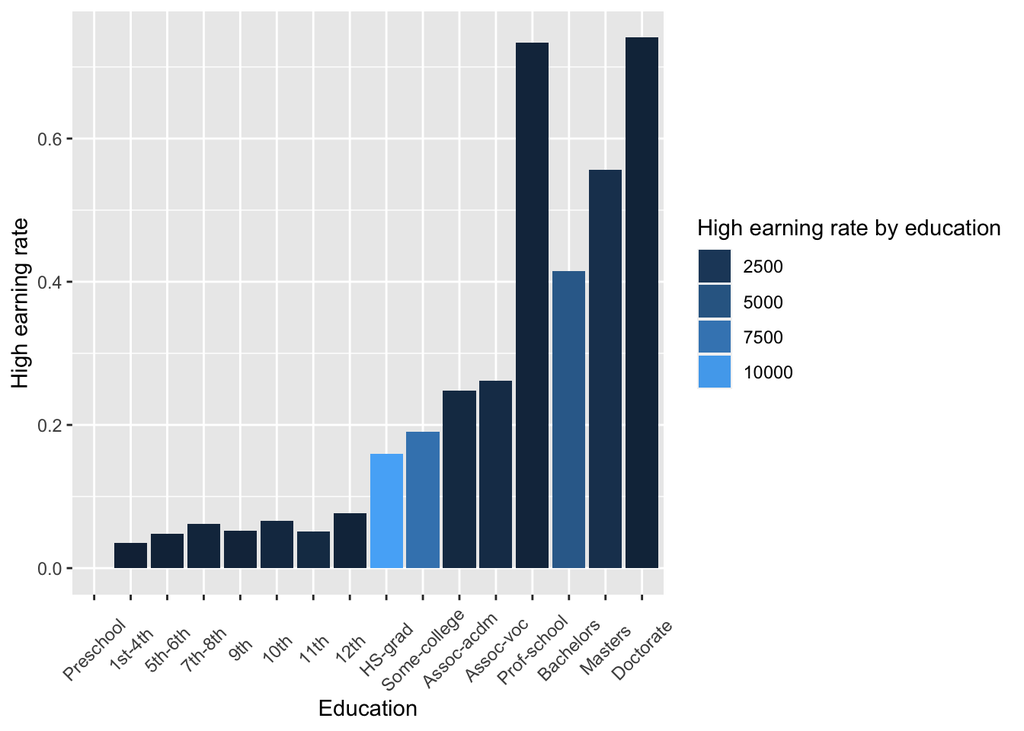

```r
high.edu <- high.edu %>%
  mutate(education = recode_factor(education, `Preschool` = "Preschool",
                                   `1st-4th` = "1st-4th", `5th-6th` = "5th-6th",
                                   `7th-8th` = "7th-8th", `9th` = "9th", `10th` = "10th", `11th` = "11th",
                                   `12th` = "12th", `HS-grad` = "HS-grad", `Some-college` = "Some-college", `Assoc-acdm` = "Assoc-acdm", `Assoc-voc` = "Assoc-voc", `Prof-school` = "Prof-school", `Bachelors` = "Bachelors", `Masters` = "Masters", `Doctorate` = "Doctorate"))


p.high.income <- ggplot(data = high.edu, aes(y = high.earn.rate, x = education, fill = count))
p.high.income + geom_bar( stat = "identity", position = "dodge") +
  ylab("High earning rate") +
  xlab("Education") +
  guides(fill = guide_legend(title = "High earning rate by education")) +
  theme(axis.text.x = element_text(angle = 45, vjust = 0.5))
```

##### (e) summary table with multiple splitting variables

Use `dplyr` functions to produce a summary table showing how the proportion of high earners varies across all combinations of the following variables: `sex`, `race`, and `marital` (marital status). In addition to showing the proportion of high earners, your table should also show the number of individuals in each bin. Your table should have column names: `sex`, `race`, `marital`, `count` and `high.earn.rate`.

```r
tbl.summary <- adult.data %>%
  group_by(sex, race, marital) %>%
  summarize(count = n(), high.earn.rate = sum(high.income)/ n() )
print(tbl.summary)
```

```
## # A tibble: 63 x 5
## # Groups:   sex, race [10]
##    sex    race               marital               count high.earn.rate
##    <chr>  <chr>              <chr>                 <int>          <dbl>
##  1 Female Amer-Indian-Eskimo Divorced                 36         0.0556
##  2 Female Amer-Indian-Eskimo Married-civ-spouse       21         0.381
##  3 Female Amer-Indian-Eskimo Married-spouse-absent     5         0
##  4 Female Amer-Indian-Eskimo Never-married            39         0.0513
##  5 Female Amer-Indian-Eskimo Separated                 8         0
##  6 Female Amer-Indian-Eskimo Widowed                  10         0
##  7 Female Asian-Pac-Islander Divorced                 51         0.0784
##  8 Female Asian-Pac-Islander Married-civ-spouse       83         0.349
##  9 Female Asian-Pac-Islander Married-spouse-absent    21         0.0476
## 10 Female Asian-Pac-Islander Never-married           161         0.0373
## # … with 53 more rows
```

##### (f) Nicer table output using `kable()`

Use the `kable()` function from the `knitr` library to display the table from part **(e)** in nice formatting. You should use the `digits` argument to ensure that the values in your table are being rounded to a reasonable number of decimal places.

```r
tbl.summary %>%
  kable(format = "markdown", digits = 3)
```

| sex | race | marital | count | high.earn.rate |
| --- | --- | --- | --- | --- |
| Female | Amer-Indian-Eskimo | Divorced | 36 | 0.056 |
| Female | Amer-Indian-Eskimo | Married-civ-spouse | 21 | 0.381 |
| Female | Amer-Indian-Eskimo | Married-spouse-absent | 5 | 0.000 |
| Female | Amer-Indian-Eskimo | Never-married | 39 | 0.051 |
| Female | Amer-Indian-Eskimo | Separated | 8 | 0.000 |
| Female | Amer-Indian-Eskimo | Widowed | 10 | 0.000 |
| Female | Asian-Pac-Islander | Divorced | 51 | 0.078 |
| Female | Asian-Pac-Islander | Married-civ-spouse | 83 | 0.349 |
| Female | Asian-Pac-Islander | Married-spouse-absent | 21 | 0.048 |
| Female | Asian-Pac-Islander | Never-married | 161 | 0.037 |
| Female | Asian-Pac-Islander | Separated | 10 | 0.100 |
| Female | Asian-Pac-Islander | Widowed | 20 | 0.100 |
| Female | Black | Divorced | 342 | 0.064 |
| Female | Black | Married-AF-spouse | 1 | 1.000 |
| Female | Black | Married-civ-spouse | 159 | 0.321 |
| Female | Black | Married-spouse-absent | 41 | 0.024 |
| Female | Black | Never-married | 723 | 0.015 |
| Female | Black | Separated | 179 | 0.017 |
| Female | Black | Widowed | 110 | 0.009 |
| Female | Other | Divorced | 17 | 0.000 |
| Female | Other | Married-civ-spouse | 20 | 0.250 |
| Female | Other | Married-spouse-absent | 7 | 0.000 |
| Female | Other | Never-married | 51 | 0.020 |
| Female | Other | Separated | 9 | 0.000 |
| Female | Other | Widowed | 5 | 0.000 |
| Female | White | Divorced | 2226 | 0.068 |
| Female | White | Married-AF-spouse | 13 | 0.385 |
| Female | White | Married-civ-spouse | 1374 | 0.481 |
| Female | White | Married-spouse-absent | 131 | 0.069 |
| Female | White | Never-married | 3793 | 0.038 |
| Female | White | Separated | 425 | 0.031 |
| Female | White | Widowed | 680 | 0.063 |
| Male | Amer-Indian-Eskimo | Divorced | 24 | 0.167 |
| Male | Amer-Indian-Eskimo | Married-civ-spouse | 95 | 0.179 |
| Male | Amer-Indian-Eskimo | Married-spouse-absent | 4 | 0.000 |
| Male | Amer-Indian-Eskimo | Never-married | 64 | 0.047 |
| Male | Amer-Indian-Eskimo | Separated | 3 | 0.000 |
| Male | Amer-Indian-Eskimo | Widowed | 2 | 0.000 |
| Male | Asian-Pac-Islander | Divorced | 24 | 0.208 |
| Male | Asian-Pac-Islander | Married-civ-spouse | 425 | 0.485 |
| Male | Asian-Pac-Islander | Married-spouse-absent | 20 | 0.150 |
| Male | Asian-Pac-Islander | Never-married | 211 | 0.071 |
| Male | Asian-Pac-Islander | Separated | 9 | 0.333 |
| Male | Asian-Pac-Islander | Widowed | 4 | 0.250 |
| Male | Black | Divorced | 143 | 0.119 |
| Male | Black | Married-civ-spouse | 678 | 0.375 |
| Male | Black | Married-spouse-absent | 21 | 0.048 |
| Male | Black | Never-married | 623 | 0.037 |
| Male | Black | Separated | 86 | 0.023 |
| Male | Black | Widowed | 18 | 0.000 |
| Male | Other | Divorced | 9 | 0.111 |
| Male | Other | Married-civ-spouse | 85 | 0.200 |
| Male | Other | Married-spouse-absent | 8 | 0.000 |
| Male | Other | Never-married | 54 | 0.019 |
| Male | Other | Separated | 4 | 0.000 |
| Male | Other | Widowed | 2 | 0.000 |
| Male | White | Divorced | 1571 | 0.164 |
| Male | White | Married-AF-spouse | 9 | 0.444 |
| Male | White | Married-civ-spouse | 12036 | 0.452 |
| Male | White | Married-spouse-absent | 160 | 0.119 |
| Male | White | Never-married | 4964 | 0.057 |
| Male | White | Separated | 292 | 0.151 |
| Male | White | Widowed | 142 | 0.268 |

**Hint**: You will have to specify the appropriate `format` argument in the `kable()` function. The notes for Lecture 6 have a working example of this.

### Problem 5: Getting the right plot

##### (a) A more complex bar chart.

Using the table you created in 4(e), use ggplot graphics to construct a plot that looks like [the one at this link](http://www.andrew.cmu.edu/user/achoulde/94842/homework/target_fig.png)

**Hint** You may find it useful to use the following layers: `facet_grid`, `coord_flip` (for horizontal bar charts), `theme` (rotating x axis text) and `guides` (removing fill legend).

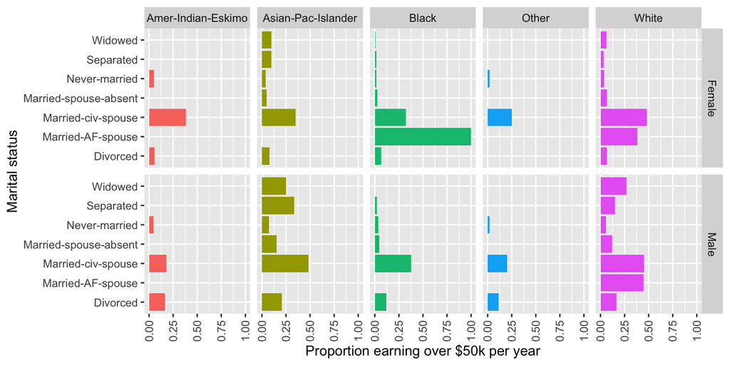

```r
tbl.summary.plot <- ggplot(data = tbl.summary, aes(x = high.earn.rate, y = marital, fill = race)) + xlab("Proportion earning over $50k per year") + ylab("Marital status") + geom_bar( stat = "identity", position = "dodge")
tbl.summary.plot + facet_grid(sex ~ race) + theme(axis.text.x = element_text(angle = 90, vjust = 0.5)) + guides(fill = FALSE)
```

##### (b) Hiding code with `echo`

Repeat part **(a)**, but this time set the `echo` argument of the code chunk in such a way that the code is not printed, but the plot is still displayed.

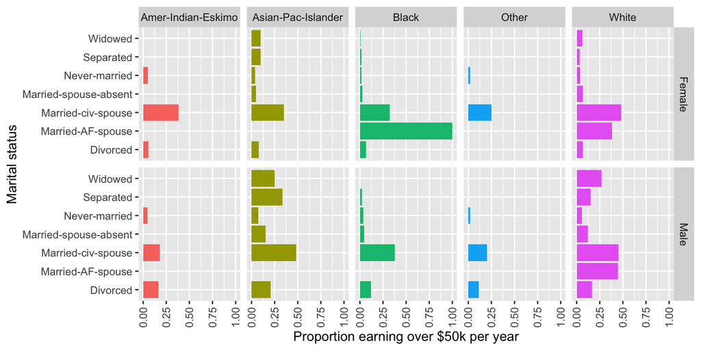